### 11월/4주

#### ▶ 정당지지도

더불어민주당 47.7%, 국민의힘 30.7%, 조국혁신당 5.0%, 개혁신당 2.8%, 기타 정당 2.1%, 지지하는 정당 없다 10.1%, 잘 모르겠다 1.5%

#### ▶ 국정평가

잘하고 있다 27.4%, 잘못하고 있다 70.6%, 잘 모르겠다 2.0%

#### ☑ 차기 대권 주자 적합도

김동연 4.8%, 안철수 1.2%, 오세훈 5.2%, 원희룡 4.2%, 이재명 43.8%, 이준석 3.6%, 조국 5.8%, 한동훈 17.2%, 홍준표 5.3%, 그 외 인물 2.0%, 없다 4.9%, 잘 모르겠다 2.1%

#### ☑ 차기 국무총리 적합도

권영세 4.7%, 윤상현 2.9%, 이정현 7.0%, 주호영 8.3%, 추경호 5.7%, 그 외 다른 인물 13.9%, 없다 44.2%, 잘 모르겠다 13.2%

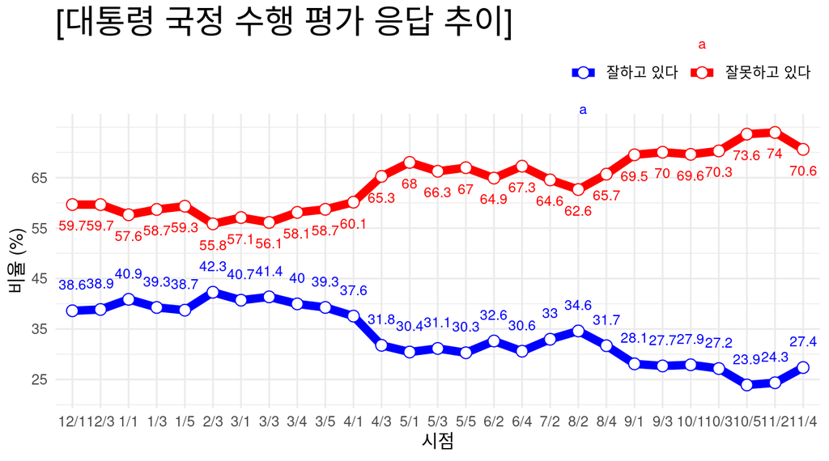

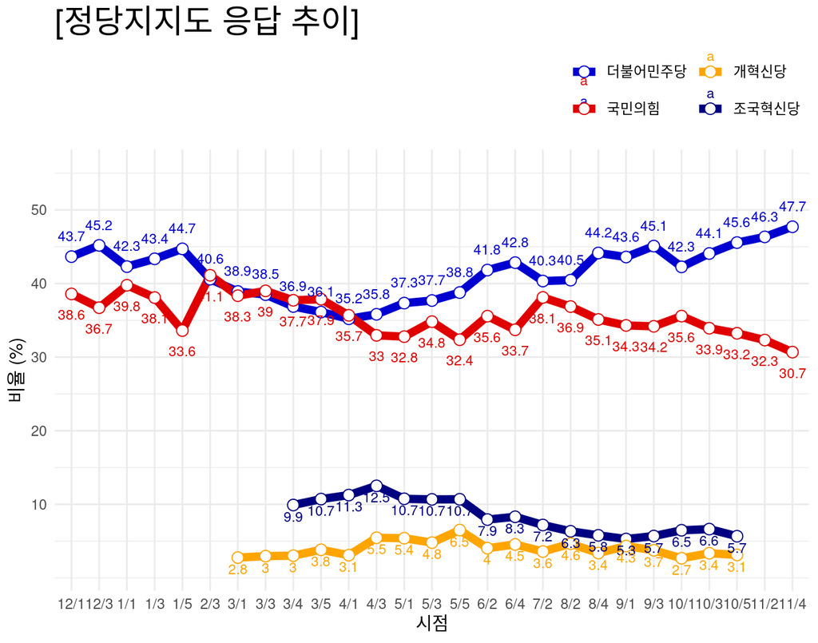

### 추가사항

- [주요질문 / 집단별 세부통계 보기](https://modernity.shinyapps.io/survey_str/) (링크누르시오)

### 참고사항

- 표본수: 2,001명,표본오차는 95% ±2.2%p
- 조사정보: 스트레이트뉴스의 의뢰로 조원씨앤아이가 2024년 11월 23일~25일 3일간

  전국 만 18세 이상 남녀를 대상으로 ARS 여론조사

  (휴대전화 100% RDD 방식, 성,연령대,지역별 비례할당 후 무작위 추출)를 실시한 결과이며,

  ※ 가중치 부여 방식: [림가중] 성별, 연령별, 지역별 가중값 부여(2024년 10월말 행정안전부 발표 주민등록인구기준)
- [중앙선거여론조사심의위원회](https://nesdc.go.kr/portal/bbs/B0000005/list.do?menuNo=200467)에서 관련사항 확인가능

2024.11.26 (화) 15:12 제작

- 연구개발 단계입니다.
- 제공: 감동과 마음의 [조원씨앤아이](http://jowoncni.com/html/index.html)